# Phylogenetic linear modeling results

# Settings

- Type of input data: “16S”
- Phenotype calculated: “specificity”
- Environment of interest: “Stool”
- Prior probabilities for environments: “uninformative”

# Phenotype calculation

Below, trees for all phyla with at least 5 representatives in the input data are presented. Trees are colored according to the phenotype chosen (here, specificity in the environment Stool).

For prevalence, the tree is colored black (low prevalence) to orange (high prevalence). For specificity, the tree is colored red for taxa that are specific for an environment, blue for taxa that are specific for other environments (i.e., found less often in the environment chosen), and gray for taxa that are neither.

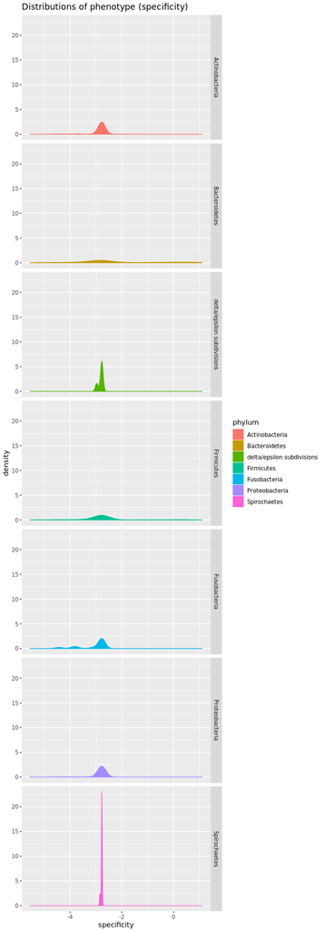

# Phenotype mapped across trees

## All taxa

[figure not shown]

## Only mapped/observed taxa

Displays phenotype on trees, with only the mapped/observed taxa plotted.

[figure not shown]

# Associations between genes and taxa

This table gives an overview of how many genes were significantly associated at an FDR of 5%.

|  | significant genes |
| --- | --- |
| firmicutes | 117 |
| actinobacteria | 105 |
| proteobacteria | 159 |
| bacteroidetes | 955 |
| delta.epsilon.subdivisions | 2 |
| spirochaetes | 89 |
| fusobacteria | 0 |

# Gene association heat maps

The left shows the phenotype painted on tips of the tree as above. The right adds a heatmap where blue points represent presence of a gene (aligned with the tips of the tree) and white points represent absence. Only significantly-associated genes are displayed. Genes are clustered from left to right by Jaccard dissimilarity, so genes with similar patterns of inheritance will form vertical stripes. Horizontal stripes may be visible for taxa that have particularly extreme phenotypes.

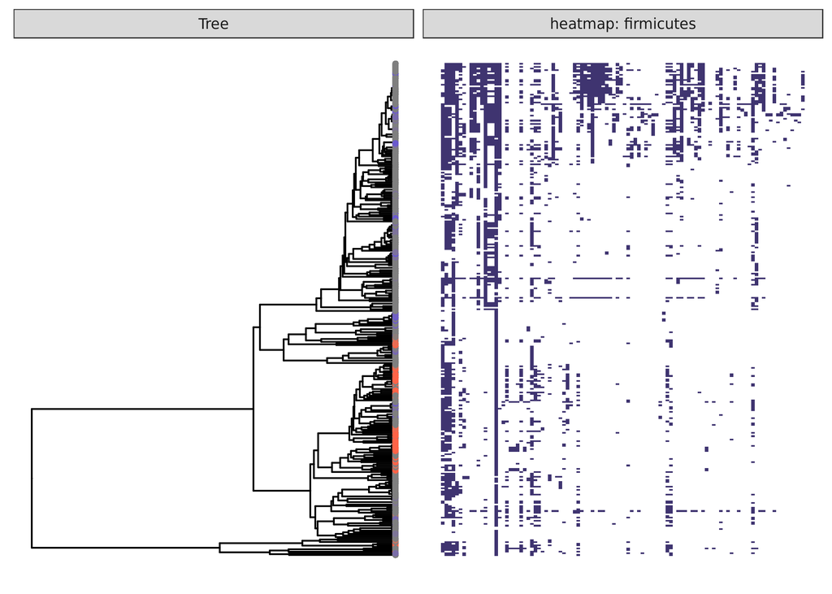

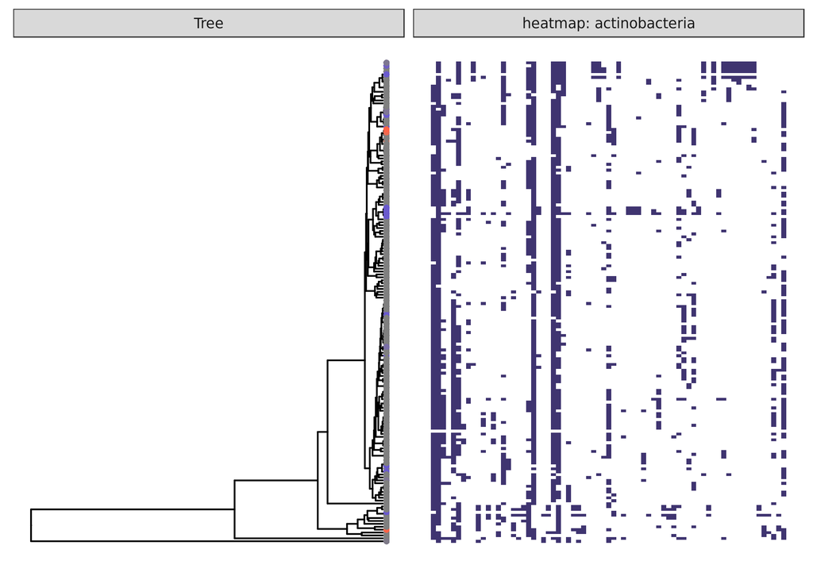

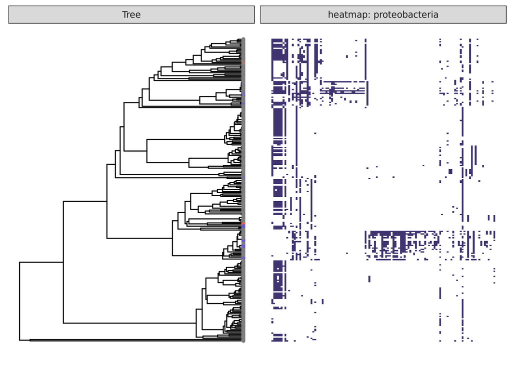

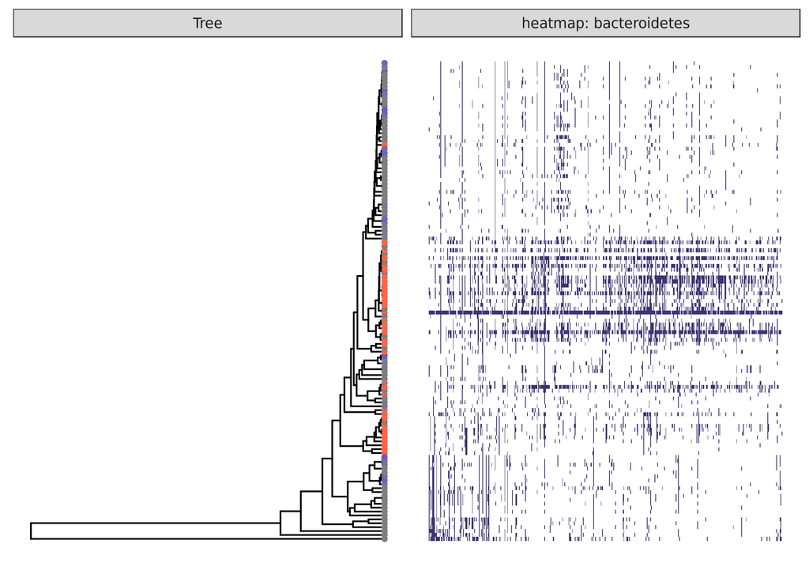

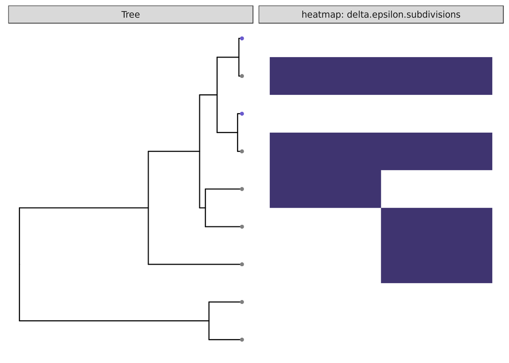

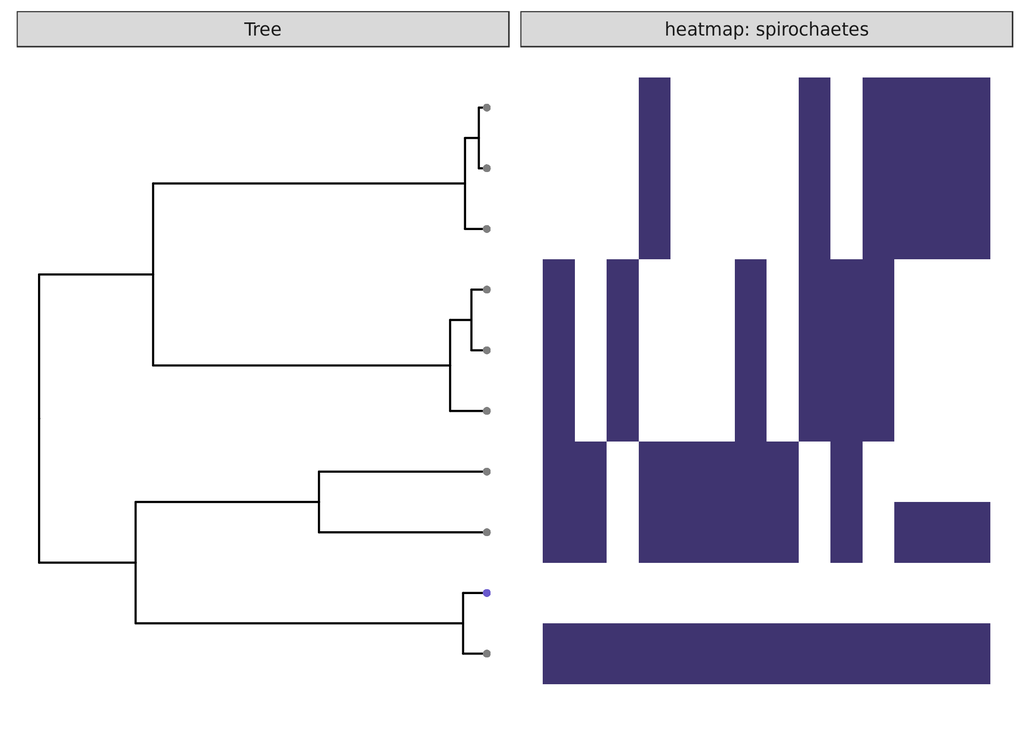

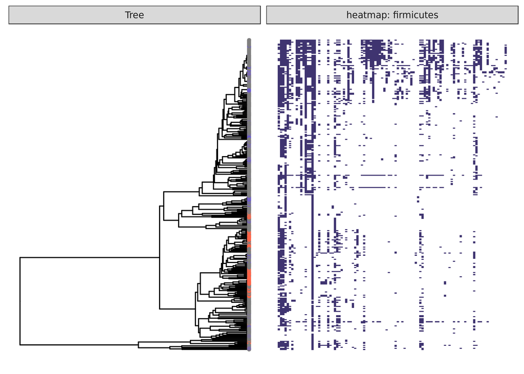

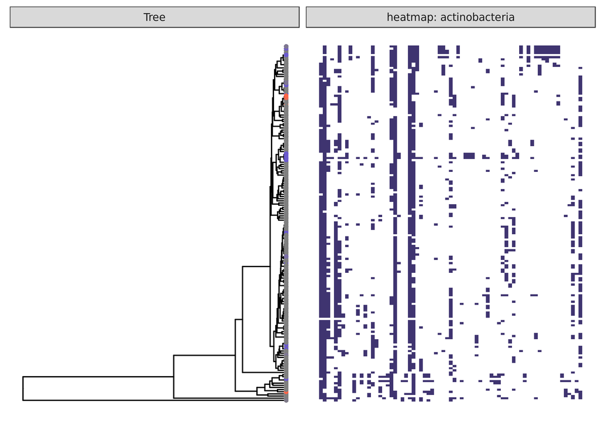

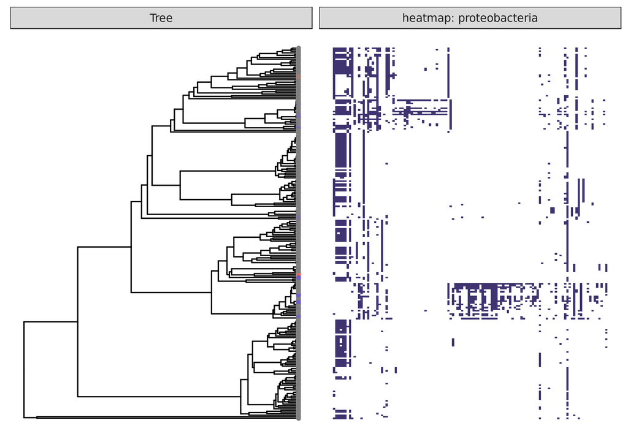

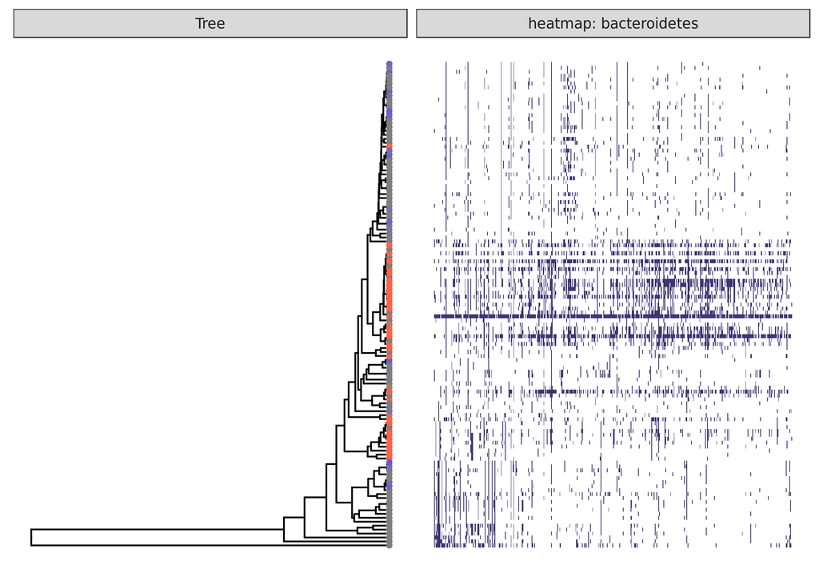

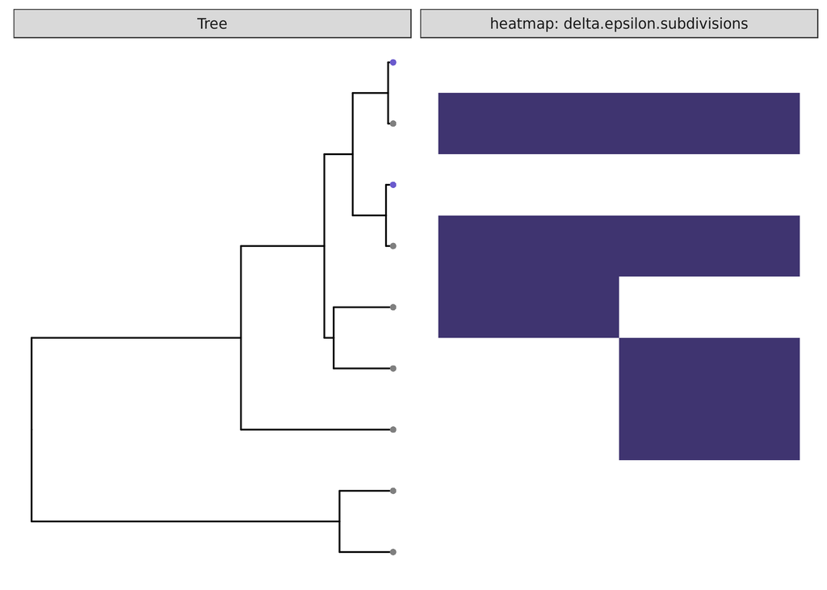

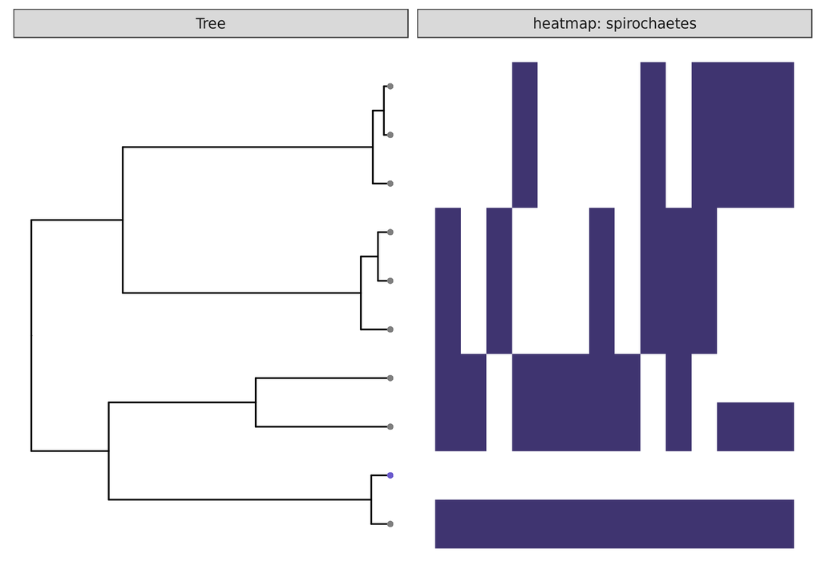

# Enrichment analysis

This process takes the set of genes that are significant and positively associated with the phenotype, then asks whether there are more than expected by chance in a given SEED subsystem. Subsystems come in three levels of granularity (referred to here as l1, l2, and l3); “l1” subsystems are the most general and “l3” are the most specific.

All SEED categories returned are significant at an FDR of 25%. “Strong”, “Med”, and “Weak” refer to per-gene significance cutoffs of 5%, 10%, and 25%, respectively.

| Gene_significance | Subsystem_level | Phylum | Subsystem | q_value |
| --- | --- | --- | --- | --- |
| Strong | L1 | Actinobacteria | Carbohydrates | 0.11 |
| Strong | L1 | Actinobacteria | RNA Metabolism | 0.12 |
| Strong | L1 | Proteobacteria | Amino Acids and Derivatives | 0.22 |
| Strong | L1 | Spirochaetes | Carbohydrates | 9.9e-05 |
| Strong | L2 | Firmicutes | Programmed Cell Death and Toxin-antitoxin Systems | 0.21 |
| Strong | L2 | Proteobacteria | Arginine; urea cycle, polyamines | 0.00036 |
| Strong | L2 | Bacteroidetes | Quinone cofactors | 0.11 |
| Strong | L2 | Spirochaetes | Monosaccharides | 5.7e-06 |
| Strong | L3 | Proteobacteria | Urea decomposition | 1.5e-07 |
| Strong | L3 | Proteobacteria | trimethylamine N-oxide (TMAO) reductase | 0.11 |
| Strong | L3 | Proteobacteria | Trehalose Uptake and Utilization | 0.24 |
| Strong | L3 | Bacteroidetes | Menaquinone Biosynthesis via Futalosine | 0.24 |
| Strong | L3 | Spirochaetes | D-allose utilization | 0.016 |
| Strong | L3 | Spirochaetes | Restriction-Modification System | 0.24 |
| Med | L1 | Firmicutes | Cofactors, Vitamins, Prosthetic Groups, Pigments | 0.037 |
| Med | L1 | Actinobacteria | Carbohydrates | 0.023 |
| Med | L1 | Actinobacteria | Amino Acids and Derivatives | 0.046 |
| Med | L1 | Actinobacteria | RNA Metabolism | 0.12 |
| Med | L1 | Proteobacteria | Amino Acids and Derivatives | 0.027 |
| Med | L1 | Bacteroidetes | Phages, Prophages, Transposable elements, Plasmids | 0.22 |
| Med | L1 | Spirochaetes | Carbohydrates | 9.9e-05 |
| Med | L2 | Firmicutes | Folate and pterines | 0.08 |
| Med | L2 | Firmicutes | Cell wall of Mycobacteria | 0.08 |
| Med | L2 | Firmicutes | Programmed Cell Death and Toxin-antitoxin Systems | 0.12 |
| Med | L2 | Proteobacteria | Arginine; urea cycle, polyamines | 5.4e-05 |
| Med | L2 | Bacteroidetes | Quinone cofactors | 0.14 |
| Med | L2 | Bacteroidetes | ABC transporters | 0.14 |
| Med | L2 | Spirochaetes | Monosaccharides | 5.7e-06 |
| Med | L3 | Firmicutes | dTDP-rhamnose synthesis | 0.088 |
| Med | L3 | Firmicutes | linker unit-arabinogalactan synthesis | 0.088 |
| Med | L3 | Firmicutes | Rhamnose containing glycans | 0.21 |
| Med | L3 | Firmicutes | Murein hydrolase regulation and cell death | 0.21 |
| Med | L3 | Proteobacteria | Urea decomposition | 4.2e-09 |
| Med | L3 | Proteobacteria | trimethylamine N-oxide (TMAO) reductase | 0.15 |
| Med | L3 | Spirochaetes | D-allose utilization | 0.016 |
| Med | L3 | Spirochaetes | Restriction-Modification System | 0.24 |
| Weak | L1 | Firmicutes | Cofactors, Vitamins, Prosthetic Groups, Pigments | 0.0018 |
| Weak | L1 | Firmicutes | Cell Wall and Capsule | 0.045 |
| Weak | L1 | Actinobacteria | Amino Acids and Derivatives | 0.0085 |
| Weak | L1 | Actinobacteria | Carbohydrates | 0.0085 |
| Weak | L1 | Actinobacteria | RNA Metabolism | 0.16 |
| Weak | L1 | Proteobacteria | Amino Acids and Derivatives | 0.0085 |
| Weak | L1 | Bacteroidetes | Phages, Prophages, Transposable elements, Plasmids | 0.018 |
| Weak | L1 | Spirochaetes | Carbohydrates | 0.00048 |
| Weak | L2 | Firmicutes | Cell wall of Mycobacteria | 0.0043 |
| Weak | L2 | Firmicutes | Capsular and extracellular polysacchrides | 0.0043 |
| Weak | L2 | Firmicutes | Protein translocation across cytoplasmic membrane | 0.0085 |
| Weak | L2 | Firmicutes | proteosome related | 0.0085 |
| Weak | L2 | Firmicutes | Folate and pterines | 0.072 |
| Weak | L2 | Firmicutes | Programmed Cell Death and Toxin-antitoxin Systems | 0.12 |
| Weak | L2 | Actinobacteria | NAD and NADP | 0.087 |
| Weak | L2 | Proteobacteria | Arginine; urea cycle, polyamines | 3e-04 |
| Weak | L2 | Bacteroidetes | ABC transporters | 0.02 |
| Weak | L2 | Bacteroidetes | Phages, Prophages | 0.02 |
| Weak | L2 | Spirochaetes | Monosaccharides | 1.9e-05 |
| Weak | L3 | Firmicutes | dTDP-rhamnose synthesis | 0.0021 |
| Weak | L3 | Firmicutes | linker unit-arabinogalactan synthesis | 0.0021 |
| Weak | L3 | Firmicutes | Thiamin biosynthesis | 0.003 |
| Weak | L3 | Firmicutes | Rhamnose containing glycans | 0.0099 |
| Weak | L3 | Firmicutes | Twin-arginine translocation system | 0.022 |
| Weak | L3 | Firmicutes | Cluster-based Subsystem Grouping Hypotheticals - perhaps Proteosome Related | 0.022 |
| Weak | L3 | Firmicutes | Sialic Acid Metabolism | 0.035 |
| Weak | L3 | Firmicutes | Murein hydrolase regulation and cell death | 0.22 |
| Weak | L3 | Actinobacteria | NAD regulation | 0.023 |
| Weak | L3 | Actinobacteria | NAD and NADP cofactor biosynthesis global | 0.071 |
| Weak | L3 | Actinobacteria | D-Tagatose and Galactitol Utilization | 0.13 |
| Weak | L3 | Actinobacteria | Tryptophan synthesis | 0.13 |
| Weak | L3 | Actinobacteria | Propanediol utilization | 0.13 |
| Weak | L3 | Actinobacteria | Branched-Chain Amino Acid Biosynthesis | 0.23 |
| Weak | L3 | Proteobacteria | Urea decomposition | 2.6e-08 |
| Weak | L3 | Bacteroidetes | LOS core oligosaccharide biosynthesis | 0.07 |
| Weak | L3 | Spirochaetes | D-allose utilization | 0.017 |
| Weak | L3 | Spirochaetes | Restriction-Modification System | 0.017 |

[output not shown]

[output not shown]